# Publicando nuestra web en la UV

Se describe el proceso para publicar nuestra web/blog en el espacio web que tenemos disponible en los servidores de la Universitat de València.

Quarto

Publicando la web

Autor

Afiliación

[Pedro J. Pérez](https://www.uv.es/pjperez/)

[Universitat de València](https://www.uv.es)

Fecha de Publicación

4 de febrero de 2023

Fecha de modificación

18 de febrero de 2024

## 1 Intro

Durante el curso hemos aprendido a generar webs/blogs con Quarto. El último paso es **subirlas a Internet**, hacerlas visibles. La documentación oficial de Quarto está [aquí](https://quarto.org/docs/publishing/)

Hay **muchas opciones para publicar nuestra web**, quizás la más sencilla es hacerlo en en [Quarto Pub](https://quarto.org/docs/publishing/quarto-pub.html): básicamente lo único que hay que hacer es ejecutar en la Terminal: `quarto publish quarto-pub`.

Nosotros, como somos personal de la UV, tenemos un espacio web en los servidores de la UV, así que vamos a ver cómo podemos alojar nuestra web allí.

## 2 Proceso

### 2.1 Activando web UV

Lo primero que necesitamos es estar seguros de que tenemos activado nuestro espacio web en la UV. Es muy probable que ya lo tengamos activado pero hay que asegurarse. ¿Cómo? Te lo explico:

1. Primero, vas a tener que acceder a https://portal.uv.es/. desde allí,
2. accedes al apartado “Mis cuentas” que está en la parte de arriba en pequeñito.

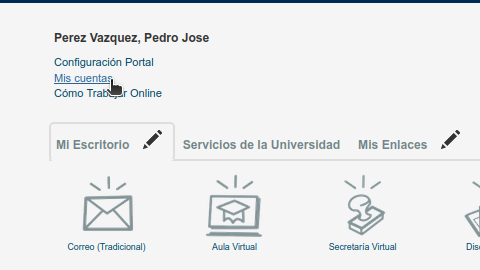

Paso 2: accede al apartado “Mis cuentas”

3. al pinchar te llevará a otra pantalla donde se puede activar y desactivar tu espacio web. Para ello solo tienes que pinchar en “Activar/Desactivar mi página web”.

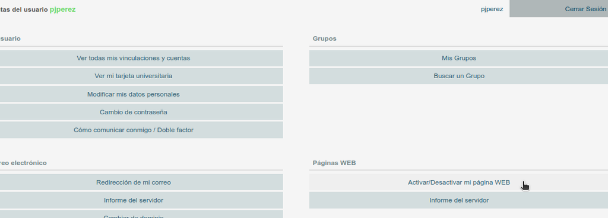

Paso 3: entra en activar/desactivar

4. Te llevará a otra pantalla donde podrás activar tu web si no la tenías activada, **PERO**, cuidado, si ya tenías activado tu espacio web, entonces lo que te permitirá es borrar tu web[^1].

### 2.2 Instalación de `Filezilla`

Para subir nuestra web al servidor de la UV **usaremos Filezilla** un programa para acceder a servidores `ftp`. Para instalar Filezilla, simplemente ve [aquí](https://filezilla-project.org/index.php) y descarga el “FileZilla client” adecuado para tu sistema operativo.

### 2.3 Subiendo nuestra web

- Abrimos Filezilla y nos conectamos a `disco.uv.es` de la UV. Hemos de poner nuestro usuario y contraseña y clickamos en conexión rápida:

[figure not shown]

- Una vez creada la conexión accederemos a nuestra carpeta de usuario, en mi caso `pjperez` en `usugru/usus`

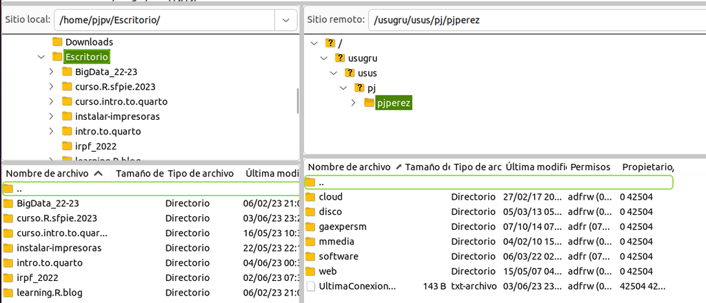

- Pinchamos en la carpeta de usuario, en mi caso `pjperez` y veremos que dentro aparece una carpeta llamada `web`, ese es nuestro espacio web en la UV

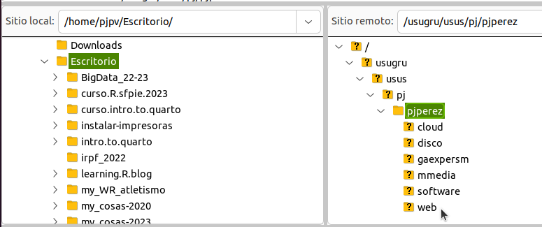

- Pincha ahora en la carpeta `web` y podrás ver en el panel inferior de Filezilla los ficheros y carpetas que tengamos en nuestro espacio web de la UV. Es posible que solo tengáis un fichero llamado `index.html`. Yo tengo además un par de carpetas ya alguna cosa más.

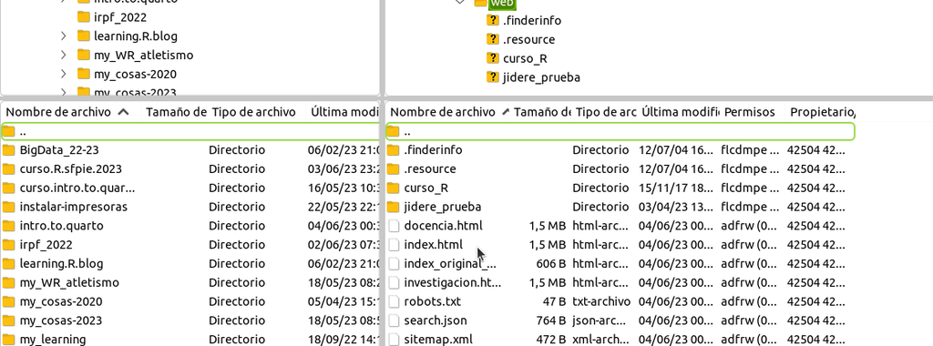

**Suerte!!** Seguro que te queda fenomenal!!

## Notas

[^1]: Si te equivocas y la borras, lo único que tendrías que hacer es volver a activarla